# English proficiency and study-abroad attitudes

August 10, 2017

## Import necessary libraries, read in and clean data

```r
library(dplyr)
library(tidyr)
library(ggplot2)
library(lme4)
library(RLRsim)
library(corrplot)
library(stringr)
library(afex)
library(mediation)
library(MASS)
library(scales)
library(car)
library(lsmeans)
library(foreign)
library(reporttools)
library(texreg)
library(PerformanceAnalytics)
setwd('C:/users/ajame/Dropbox/English_stress')
data <- read.csv('All_Data_Original_truncated.csv', stringsAsFactors = FALSE)
```

First we’ll rename some of our variables & label the factors. We’ll create special versions of the factors for IELTS / TOEFL scores including data from those that took the test only, and versions of factors where levels that are highly underrepresented are eliminated. We’ll also create numeric versions of variables that are pseudo-interval / ratio scale.

```r
data <-data %>% rename(sex = Q1, urban = Q2, wealth_class = Q3, country = Q4, still_abroad = Q5, duration = Q6, major = Q7, traveled_before = Q8, overall_score = Q10, speaking_score = Q11, native_friends = Q48_A1, call_native_friends = Q49_A1, sex_native = Q50, sex_chinese = Q51, community = Q52_A1, bars_chinese = Q53_A1, bars_native = Q54_A1 )



data$sex <- factor(data$sex, labels = c("Male", "Female"))

data$urban <- factor(data$urban, labels = c("Country", "Urban"))

data$wealth_class <- factor(data$wealth_class, labels= c("Lower Class", "Lower-middle class", "Middle class", "Upper-middle class", "Upper class", "Extremely Wealthy")) # note that "extremely wealthy" response is very uncommon and probably not a valid factor level for analysis; upper and lower class are also relatively uncommons
data$wealth_class_trimmed <- data$wealth_class
data$wealth_class_trimmed[data$wealth_class_trimmed == "Extremely Wealthy"] <- NA
data$wealth_class_no_extreme <- data$wealth_class
data$wealth_class_no_extreme[data$wealth_class_no_extreme == "Extremely Wealthy"] <- "Upper class"
data$wealth_class_no_extreme <- factor(data$wealth_class_no_extreme, ordered = FALSE)

data$country <- factor(data$country, labels= c("USA", "Canada", "UK / Ireland", "Australia / New Zealand", "Germany / France / Holland", "Korea / Japan / Singapore", "Other"))

data$still_abroad <- factor(data$still_abroad, labels= c("Still abroad", "Already returned"))

data$duration_numeric <- dplyr::recode(data$duration, `1`=0.5, `2`=1, `3`=1.5, `4`=2, `5`=3, `6`=4)

data$duration <- factor(data$duration, labels= c("0.5 years", "1 year", "1.5 years", "2 years", "3 Years", "4 years or more"), ordered = TRUE)

data$major <- factor(data$major, labels= c("STEM", "Social sciences", "Business", "Arts", "Languages", "Other"))

data$took_test <- factor(data$overall_score != 10, labels = c("Did not take test", "Took test"))

data$overall_score_numeric <- dplyr::recode(data$overall_score, `1` = 5, `2` = 5.5, `3` = 6, `4` = 6.5, `5` = 7, `6` = 7.5, `7` = 8, `8` = 8.5, `9` = 9, `10` = NULL, `11` = 4.5) # extreme values - IELTS < 5.5 and IELTS > 8 are poorly represented in the data
data$overall_score_numeric_trimmed <- data$overall_score_numeric
data$overall_score_numeric_trimmed[data$overall_score_numeric_trimmed < 5.5 | data$overall_score_numeric_trimmed > 8] <- NA

data$overall_score <- factor(data$overall_score, levels=levels(factor(data$overall_score))[c(11,1:10)], labels = c("IELTS 4.5 TOEFL 32-34", "IELTS 5 TOEFL 35-45", "IELTS 5.5 TOEFL 46-59", "IELTS 6 TOEFL 60-78", "IELTS 6.5 TOEFL 79-93", "IELTS 7 TOEFL 94-101", "IELTS 7.5 TOEFL 102-109", "IELTS 8 TOEFL 110-114", "IELTS 8.5 TOEFL 115-117", "IELTS 9 TOEFL 118-120", "Did not take"), ordered = TRUE)

data$overall_score_takers <- data$overall_score
data$overall_score_takers[data$overall_score_takers == "Did not take"] <- NA
data$overall_score_takers <- factor(data$overall_score_takers)

data$overall_score_trimmed <- data$overall_score
data$overall_score_trimmed[data$overall_score_trimmed %in% c("IELTS 4.5 TOEFL 32-34", "IELTS 5 TOEFL 35-45", "IELTS 8.5 TOEFL 115-117", "IELTS 9 TOEFL 118-120")] <- NA
data$overall_score_trimmed <- factor(data$overall_score_trimmed)

data$overall_score_trimmed_takers <- data$overall_score_trimmed
data$overall_score_trimmed_takers[data$overall_score_trimmed_takers == "Did not take"] <- NA
data$overall_score_trimmed_takers <- factor(data$overall_score_trimmed_takers)

data$took_speaking_test <- factor(data$speaking_score != 10, labels = c("Did not take test", "Took test"))

data$speaking_score_numeric <- dplyr::recode(data$speaking_score, `1` = 5, `2` = 5.5, `3` = 6, `4` = 6.5, `5` = 7, `6` = 7.5, `7` = 8, `8` = 8.5, `9` = 9, `10` = NULL, `11` = 4.5)  # extreme values - IELTS < 5.5 and IELTS > 8 are poorly represented in the data
data$speaking_score_numeric_trimmed <- data$speaking_score_numeric
data$speaking_score_numeric_trimmed[data$speaking_score_numeric_trimmed < 5.5 | data$speaking_score_numeric_trimmed > 8] <- NA

data$speaking_score <- factor(data$speaking_score, levels=levels(factor(data$speaking_score))[c(11,1:10)], labels= c("IELTS 4.5 TOEFL 12-13", "IELTS 5 TOEFL 14-15", "IELTS 5.5 TOEFL 16-18", "IELTS 6 TOEFL 19-20", "IELTS 6.5 TOEFL 21-22", "IELTS 7 TOEFL 23", "IELTS 7.5 TOEFL 24-25", "IELTS 8 TOEFL 26-27", "IELTS 8.5 TOEFL 28-29", "IELTS 9 TOEFL 30", "Did not take"), ordered = TRUE)

data$speaking_score_takers <- data$speaking_score
data$speaking_score_takers[data$speaking_score_takers == "Did not take"] <- NA
data$speaking_score_takers <- factor(data$speaking_score_takers)

data$speaking_score_trimmed <- data$speaking_score
data$speaking_score_trimmed[data$speaking_score_trimmed %in% c("IELTS 4.5 TOEFL 12-13", "IELTS 5 TOEFL 14-15", "IELTS 8.5 TOEFL 28-29", "IELTS 9 TOEFL 30")] <- NA
data$speaking_score_trimmed <- factor(data$speaking_score_trimmed)

data$speaking_score_trimmed_takers <- data$speaking_score_trimmed
data$speaking_score_trimmed_takers[data$speaking_score_trimmed_takers == "Did not take"] <- NA
data$speaking_score_trimmed_takers <- factor(data$speaking_score_trimmed_takers)

data$sex_native <- factor(data$sex_native, levels = levels(factor(data$sex_native))[c(2,1)], labels = c("No", "Yes"))
data$sex_chinese <- factor(data$sex_chinese, levels = levels(factor(data$sex_chinese))[c(2,1)], labels = c("No", "Yes"))
data$traveled_before <- factor(data$traveled_before, levels = levels(factor(data$traveled_before))[c(2,1)], labels= c("Never abroad before", "Abroad before"))
```

## Demographic data

```r
#tableNominal(vars = data %>% dplyr::select(sex, wealth_class, urban, traveled_before, country, duration, overall_score, major), vertical = FALSE, lab = "tab: nominal1", longtable = TRUE, cumsum = FALSE, cap = "Demographic characteristics of sample", nams = c('Sex', 'Wealth class', 'Home', 'Prior travel abroad', 'Study abroad country', 'Duration abroad', 'Test score', 'Major'))
```

## Check for missing data & correlation exploration

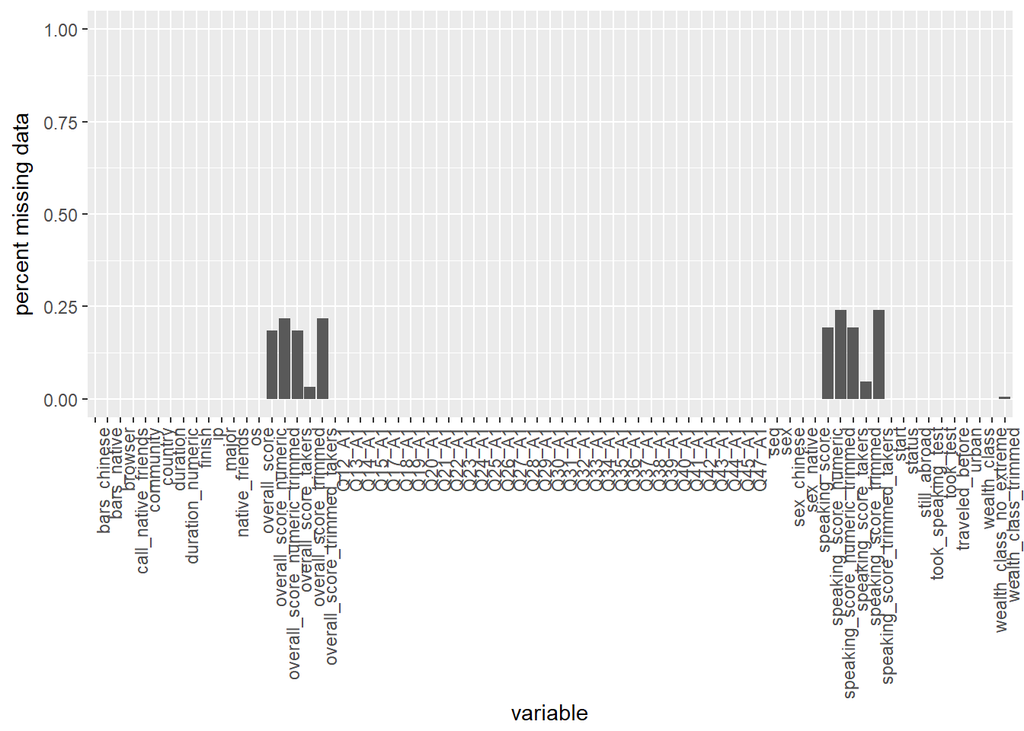

```r
naPercent <- data %>% summarize_all(funs(sum(is.na(.))/n())) %>% gather(key="variable", value="missing_percent")
ggplot(naPercent, aes(x=variable, y=missing_percent)) + geom_bar(stat="identity") + theme(axis.text.x = element_text(hjust = 1, angle = 90)) + scale_y_continuous("percent missing data", limits=c(0,1))
```

No data is missing except for where we explicitly induced missing data. Let’s start converting the appropriate variables to factors.

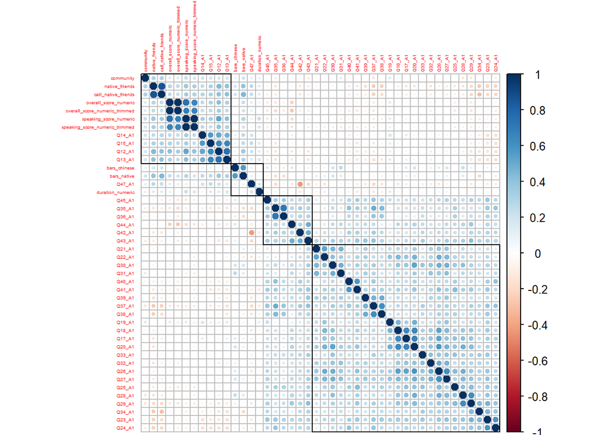

```r
correls <- cor(dplyr::select_if(data, is.numeric) %>% dplyr::select(-seq, -status),  use = "pairwise.complete.obs")
corrplot(correls, order= "hclust", hclust.method = "complete", addrect = 4, rect.lwd = 1, tl.cex = .3)
```

Subsets of variables: our english confidence measures (Q12-Q15) and stress measures (Q17-Q45)

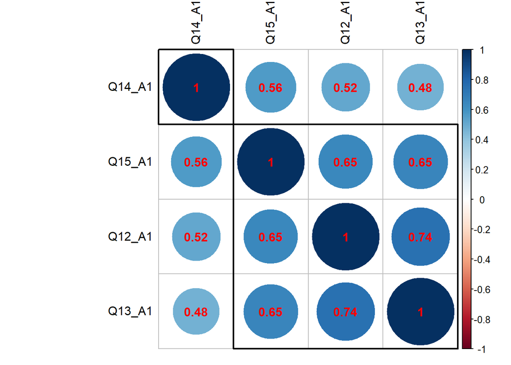

```
##           Q14_A1    Q15_A1    Q12_A1    Q13_A1
## Q14_A1 1.0000000 0.5620220 0.5185004 0.4776175
## Q15_A1 0.5620220 1.0000000 0.6466257 0.6535074
## Q12_A1 0.5185004 0.6466257 1.0000000 0.7427270
## Q13_A1 0.4776175 0.6535074 0.7427270 1.0000000
```

```r
correls <- cor(data[,str_c('Q', seq(12, 15), '_A1')])
print(corrplot(correls, order = "hclust", hclust.method = "complete", addrect = 2, rect.lwd = 2, tl.col = "black", addCoef.col = 'red'))
```

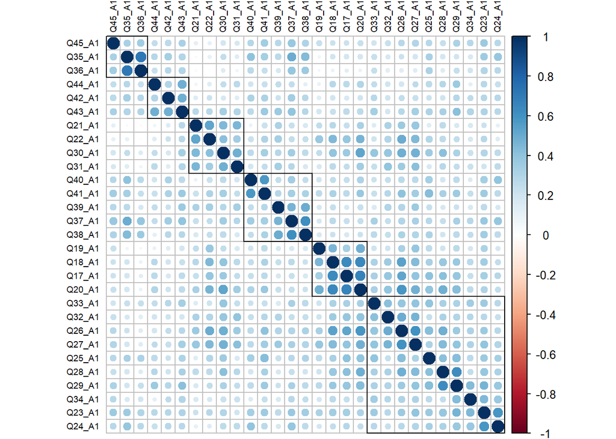

```
##           Q45_A1     Q35_A1      Q36_A1     Q44_A1    Q42_A1    Q43_A1
## Q45_A1 1.0000000 0.32852254  0.34240639 0.24875019 0.2667202 0.3261641
## Q35_A1 0.3285225 1.00000000  0.71998966 0.28853075 0.3346569 0.2951666
## Q36_A1 0.3424064 0.71998966  1.00000000 0.22636526 0.2828960 0.2962824
## Q44_A1 0.2487502 0.28853075  0.22636526 1.00000000 0.2929734 0.4824373
## Q42_A1 0.2667202 0.33465688  0.28289595 0.29297341 1.0000000 0.4878840
## Q43_A1 0.3261641 0.29516660  0.29628243 0.48243730 0.4878840 1.0000000
## Q21_A1 0.1172716 0.03359724 -0.03743454 0.06754335 0.1476362 0.2798801
## Q22_A1 0.1097452 0.10108119  0.02597561 0.13965936 0.2114380 0.2718953
## Q30_A1 0.1823539 0.24760428  0.14751350 0.24241037 0.1707464 0.3379615
## Q31_A1 0.1713977 0.13874993  0.06553923 0.26094423 0.1360576 0.2977395
## Q40_A1 0.2823050 0.40383656  0.26182049 0.19483062 0.3165319 0.2642303
## Q41_A1 0.3436279 0.33500277  0.23444761 0.22925701 0.3181222 0.3652849
## Q39_A1 0.2761284 0.26490768  0.17911907 0.24426829 0.2148236 0.3682778
## Q37_A1 0.3769268 0.49264394  0.38141323 0.24772066 0.3440547 0.3910640
## Q38_A1 0.3022819 0.43590495  0.36456826 0.11392232 0.2750687 0.2814172
## Q19_A1 0.2226985 0.06522338  0.05165880 0.09263742 0.1351451 0.1896146
## Q18_A1 0.2149130 0.19917860  0.08809779 0.27117701 0.1993485 0.2275279
## Q17_A1 0.2141231 0.18570067  0.12224375 0.26422233 0.1676001 0.2517736
## Q20_A1 0.2297482 0.18740882  0.08543147 0.29168143 0.2012588 0.2559934
## Q33_A1 0.1981505 0.22870467  0.23783462 0.24819631 0.2748008 0.3378207
## Q32_A1 0.2219153 0.17558086  0.12871088 0.19040544 0.2059927 0.1862129
## Q26_A1 0.2727544 0.21072186  0.13729675 0.18891973 0.2481785 0.2727666
## Q27_A1 0.2994033 0.18699068  0.13216088 0.25009079 0.2295697 0.3372429
## Q25_A1 0.2712351 0.32472338  0.31164969 0.25199513 0.2105711 0.3080282
## Q28_A1 0.2351469 0.18881949  0.14580317 0.28685908 0.2016138 0.3255304
## Q29_A1 0.3181362 0.19232975  0.23380243 0.36340317 0.2835501 0.4119503
## Q34_A1 0.2765228 0.16746856  0.19088203 0.11017820 0.2502479 0.2958574
## Q23_A1 0.3624822 0.35332245  0.29097941 0.27749682 0.2863765 0.3008900
## Q24_A1 0.2756742 0.38726147  0.27248223 0.22927260 0.2722631 0.2772823
##             Q21_A1     Q22_A1    Q30_A1     Q31_A1     Q40_A1    Q41_A1
## Q45_A1  0.11727163 0.10974522 0.1823539 0.17139772 0.28230502 0.3436279
## Q35_A1  0.03359724 0.10108119 0.2476043 0.13874993 0.40383656 0.3350028
## Q36_A1 -0.03743454 0.02597561 0.1475135 0.06553923 0.26182049 0.2344476
## Q44_A1  0.06754335 0.13965936 0.2424104 0.26094423 0.19483062 0.2292570
## Q42_A1  0.14763623 0.21143800 0.1707464 0.13605757 0.31653194 0.3181222
## Q43_A1  0.27988006 0.27189534 0.3379615 0.29773947 0.26423030 0.3652849
## Q21_A1  1.00000000 0.52533993 0.4407687 0.45805966 0.08418099 0.2173208
## Q22_A1  0.52533993 1.00000000 0.4164842 0.34324538 0.21876131 0.3049912
## Q30_A1  0.44076872 0.41648423 1.0000000 0.48138065 0.25751673 0.3323987
```

[output cut: 95 more lines]

```
## Q38_A1 0.1920051 0.2645847 0.2479939 0.3479343 0.2596791
## Q19_A1 0.2002173 0.2617356 0.1809231 0.3138189 0.1814910
## Q18_A1 0.3755344 0.3744397 0.2694347 0.3470663 0.2457060
## Q17_A1 0.4187917 0.3808290 0.2398686 0.3341946 0.2840663
## Q20_A1 0.4861049 0.4223823 0.2545390 0.3081778 0.2431612
## Q33_A1 0.3239711 0.3137528 0.3429550 0.3522096 0.2742718
## Q32_A1 0.3194919 0.2951264 0.2810098 0.2758445 0.2282094
## Q26_A1 0.4889229 0.3690669 0.3005138 0.3627214 0.2727079
## Q27_A1 0.4379547 0.3970182 0.3046430 0.3984870 0.2944243
## Q25_A1 0.4147638 0.4287416 0.2657283 0.3663766 0.3303235
## Q28_A1 1.0000000 0.6207771 0.2408956 0.3808010 0.3184995
## Q29_A1 0.6207771 1.0000000 0.4396733 0.4667551 0.3759791
## Q34_A1 0.2408956 0.4396733 1.0000000 0.4405226 0.3779485
## Q23_A1 0.3808010 0.4667551 0.4405226 1.0000000 0.5865368
## Q24_A1 0.3184995 0.3759791 0.3779485 0.5865368 1.0000000
```

```r
correls <- cor(data[,str_c('Q', seq(17,45), '_A1')])
print(corrplot(correls, order = "hclust", hclust.method = "complete", addrect = 6, rect.lwd = 1, tl.cex = .6, tl.col = "black"))
```

## Calcualte alphas, summary scales

Calculate Cronbach’s alpha for English ability items (12-15) and study abroad stress (17-45)

```r
psych::alpha(data[,str_c('Q', seq(12, 15), '_A1')])
```

```
##
## Reliability analysis
## Call: psych::alpha(x = data[, str_c("Q", seq(12, 15), "_A1")])
##
##   raw_alpha std.alpha G6(smc) average_r S/N   ase mean   sd
##       0.85      0.86    0.83       0.6   6 0.013  3.5 0.82
##
##  lower alpha upper     95% confidence boundaries
## 0.82 0.85 0.87
##
##  Reliability if an item is dropped:
##        raw_alpha std.alpha G6(smc) average_r S/N alpha se
## Q12_A1      0.79      0.80    0.73      0.56 3.9    0.019
## Q13_A1      0.80      0.80    0.74      0.58 4.1    0.019
## Q14_A1      0.86      0.86    0.81      0.68 6.4    0.013
## Q15_A1      0.79      0.81    0.76      0.58 4.1    0.020
##
##  Item statistics
##          n raw.r std.r r.cor r.drop mean   sd
## Q12_A1 361  0.86  0.87  0.83   0.74  3.5 0.92
## Q13_A1 361  0.84  0.86  0.81   0.73  3.5 0.86
## Q14_A1 361  0.79  0.76  0.63   0.59  3.3 1.13
## Q15_A1 361  0.86  0.86  0.79   0.73  3.6 1.00
##
## Non missing response frequency for each item
##           1    2    3    4    5 miss
## Q12_A1 0.02 0.10 0.41 0.32 0.14    0
## Q13_A1 0.02 0.07 0.43 0.35 0.12    0
## Q14_A1 0.06 0.16 0.40 0.20 0.19    0
## Q15_A1 0.03 0.10 0.32 0.37 0.18    0
```

```r
psych::alpha(data[,str_c('Q', seq(17, 45), '_A1')])
```

```
##
## Reliability analysis
## Call: psych::alpha(x = data[, str_c("Q", seq(17, 45), "_A1")])
##
##   raw_alpha std.alpha G6(smc) average_r S/N    ase mean   sd
##       0.92      0.92    0.94      0.29  12 0.0061  2.1 0.59
##
##  lower alpha upper     95% confidence boundaries
## 0.91 0.92 0.93
##
##  Reliability if an item is dropped:
##        raw_alpha std.alpha G6(smc) average_r S/N alpha se
## Q17_A1      0.92      0.92    0.94      0.29  11   0.0063
## Q18_A1      0.92      0.92    0.94      0.29  11   0.0064
## Q19_A1      0.92      0.92    0.94      0.30  12   0.0062
## Q20_A1      0.91      0.92    0.94      0.29  11   0.0064
## Q21_A1      0.92      0.92    0.94      0.30  12   0.0062
## Q22_A1      0.92      0.92    0.94      0.29  12   0.0063
## Q23_A1      0.91      0.92    0.94      0.29  11   0.0064
## Q24_A1      0.92      0.92    0.94      0.29  12   0.0063
## Q25_A1      0.92      0.92    0.94      0.29  11   0.0064
## Q26_A1      0.91      0.92    0.94      0.29  11   0.0064
## Q27_A1      0.91      0.92    0.94      0.29  11   0.0064
## Q28_A1      0.92      0.92    0.94      0.29  11   0.0063
## Q29_A1      0.91      0.92    0.94      0.29  11   0.0064
## Q30_A1      0.92      0.92    0.94      0.29  11   0.0063
## Q31_A1      0.92      0.92    0.94      0.29  12   0.0062
## Q32_A1      0.92      0.92    0.94      0.29  12   0.0063
## Q33_A1      0.92      0.92    0.94      0.29  12   0.0063
## Q34_A1      0.92      0.92    0.94      0.29  12   0.0062
## Q35_A1      0.92      0.92    0.94      0.29  12   0.0063
## Q36_A1      0.92      0.92    0.94      0.30  12   0.0061
## Q37_A1      0.92      0.92    0.94      0.29  11   0.0064
## Q38_A1      0.92      0.92    0.94      0.29  12   0.0063
## Q39_A1      0.92      0.92    0.94      0.29  12   0.0062
## Q40_A1      0.92      0.92    0.94      0.29  12   0.0063
## Q41_A1      0.92      0.92    0.94      0.29  11   0.0064
## Q42_A1      0.92      0.92    0.94      0.29  12   0.0062
## Q43_A1      0.92      0.92    0.94      0.29  11   0.0063
## Q44_A1      0.92      0.92    0.94      0.30  12   0.0062
```

[output cut: 50 more lines]

```
## Q31_A1 0.92 0.04 0.02 0.00 0.01    0
## Q32_A1 0.69 0.15 0.11 0.04 0.01    0
## Q33_A1 0.35 0.25 0.26 0.10 0.04    0
## Q34_A1 0.26 0.19 0.28 0.16 0.11    0
## Q35_A1 0.11 0.19 0.40 0.18 0.12    0
## Q36_A1 0.07 0.14 0.32 0.25 0.22    0
## Q37_A1 0.45 0.30 0.19 0.04 0.02    0
## Q38_A1 0.29 0.32 0.26 0.10 0.03    0
## Q39_A1 0.67 0.18 0.12 0.02 0.01    0
## Q40_A1 0.37 0.20 0.27 0.11 0.05    0
## Q41_A1 0.48 0.24 0.19 0.06 0.04    0
## Q42_A1 0.30 0.19 0.26 0.10 0.15    0
## Q43_A1 0.47 0.32 0.15 0.04 0.03    0
## Q44_A1 0.29 0.28 0.31 0.08 0.04    0
## Q45_A1 0.17 0.21 0.34 0.17 0.10    0
```

Alpha’s are good! Let’s calculate scales (english confidence and stress levels) and plot the dependent measure (stress)

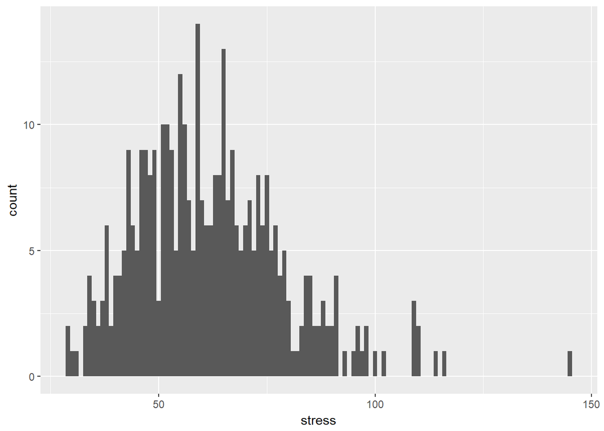

```r
data <- data %>% mutate(english_confidence = rowSums(.[str_c('Q', seq(12, 15), '_A1')]))
data <- data %>% mutate(stress = rowSums(.[str_c('Q', seq(17, 45), '_A1')]))

print(ggplot(data, aes(stress)) + geom_histogram(binwidth = 1))
```

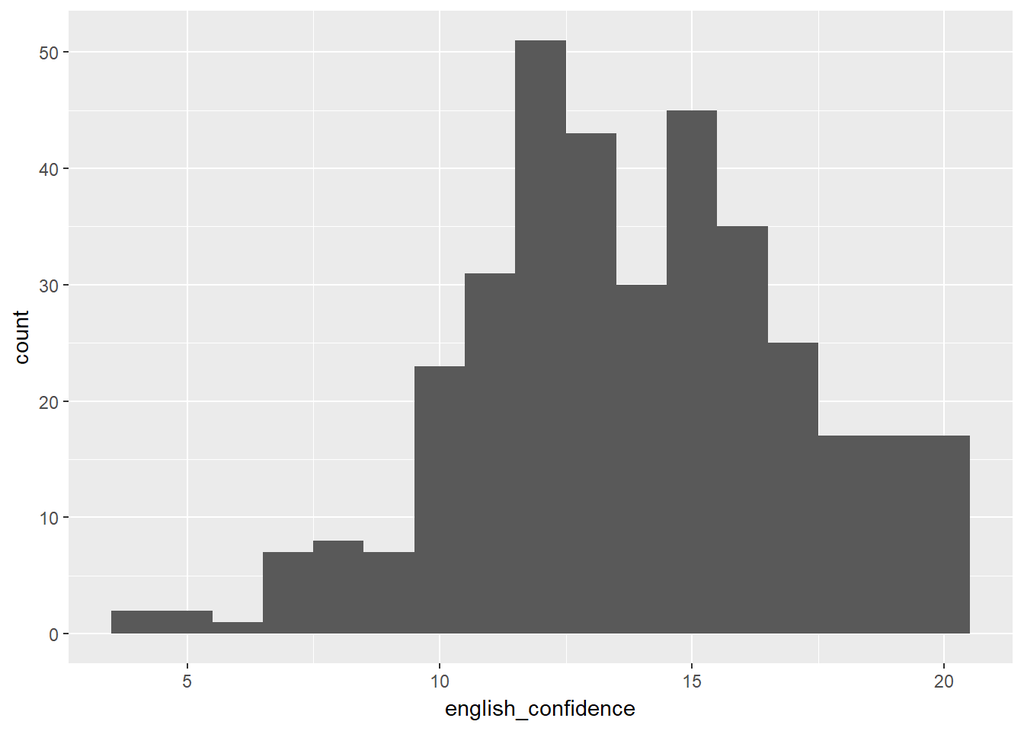

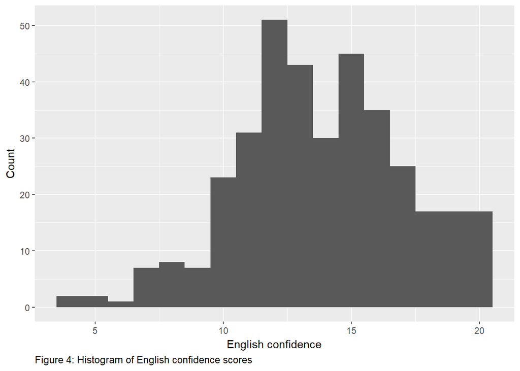

```r
print(ggplot(data, aes(english_confidence)) + geom_histogram(binwidth = 1)) + labs(x="English confidence", y="Count", caption = "Figure 4: Histogram of English confidence scores") + theme(plot.caption=element_text(hjust=0))
```

Looks like an outlier at ~ 140, let’s filter and re-plot. Then let’s see what the highest correlations with stress are.

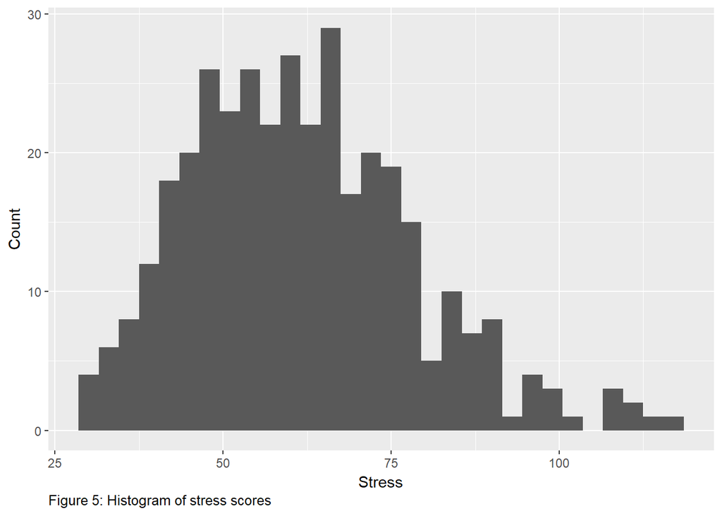

```r
filtered <- data %>% filter(stress < 130)
ggplot(filtered, aes(stress)) + geom_histogram() + labs(x="Stress", y="Count", caption = "Figure 5: Histogram of stress scores") + theme(plot.caption=element_text(hjust=0))
```

Looks reasonably normally-distributed, might benefit from a log transformation but… We should probably re-calculate alpha’s as well, with the filtered data.

But first let’s replot our correlations plot to look for patterns in the data with our new summary measures.

```r
elim <- c(str_c('Q',seq(12, 15), '_A1'), str_c('Q', seq(17, 49), '_A1'))
numeric_vars <- dplyr::select(filtered, -c(1:7)) %>% dplyr::select(which(!colnames(.) %in% elim)) %>% mutate_all(as.numeric)
correls <- cor(numeric_vars,  use = "pairwise.complete.obs")
```

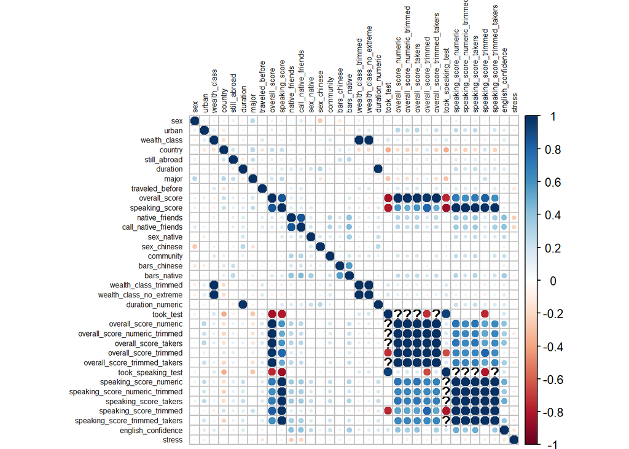

```r
corrplot(correls,  tl.cex = .5 , tl.col = "black")
```

```r
sort(abs(correls[,'stress']))
```

```
##                   still_abroad                     sex_native
##                   4.846593e-05                   9.590382e-03
##                        country                      took_test
##                   1.775013e-02                   2.741645e-02
##             took_speaking_test               duration_numeric
##                   4.161986e-02                   4.260119e-02
##           wealth_class_trimmed                       duration
##                   4.494875e-02                   4.599403e-02
##        wealth_class_no_extreme                   wealth_class
##                   4.614176e-02                   4.630526e-02
##                    sex_chinese                            sex
##                   4.671088e-02                   4.962594e-02
##                  overall_score          overall_score_numeric
##                   5.328315e-02                   5.878870e-02
##           overall_score_takers                    bars_native
##                   5.878870e-02                   6.066555e-02
##                      community         speaking_score_numeric
##                   6.768621e-02                   6.890142e-02
##          speaking_score_takers                 speaking_score
##                   6.890142e-02                   6.897921e-02
##                          major                   bars_chinese
##                   7.532526e-02                   8.370950e-02
##          overall_score_trimmed                          urban
##                   8.617199e-02                   8.685166e-02
##         speaking_score_trimmed speaking_score_numeric_trimmed
##                   9.343179e-02                   9.507400e-02
##  speaking_score_trimmed_takers  overall_score_numeric_trimmed
##                   9.507400e-02                   1.044113e-01
##   overall_score_trimmed_takers                traveled_before
##                   1.044113e-01                   1.315451e-01
##             english_confidence            call_native_friends
##                   1.343782e-01                   2.143226e-01
##                 native_friends                         stress
##                   2.571252e-01                   1.000000e+00
```

## Simple linear models involving English confidence

…we’ll look at the residuals from the statistical models before attempting that. Try a simple linear model first, predicting reported stress levels from our english confidence measure, including sex and whether the subject has traveled before as covariates.

```r
stressModel <- lm(stress ~ english_confidence + sex + traveled_before, data = filtered)
summary(stressModel)
```

```
##
## Call:
## lm(formula = stress ~ english_confidence + sex + traveled_before,
##     data = filtered)
##
## Residuals:
##     Min      1Q  Median      3Q     Max
## -36.816 -11.599  -1.843  10.526  51.267
##
## Coefficients:
##                              Estimate Std. Error t value Pr(>|t|)
## (Intercept)                   72.7467     3.9543  18.397   <2e-16 ***
## english_confidence            -0.6243     0.2679  -2.330   0.0204 *
## sexFemale                     -1.7706     1.8477  -0.958   0.3386
## traveled_beforeAbroad before  -4.4336     1.8889  -2.347   0.0195 *
## ---
## Signif. codes:  0 '***' 0.001 '**' 0.01 '*' 0.05 '.' 0.1 ' ' 1
##
## Residual standard error: 16.43 on 356 degrees of freedom
## Multiple R-squared:  0.03501,    Adjusted R-squared:  0.02688
## F-statistic: 4.305 on 3 and 356 DF,  p-value: 0.005322
```

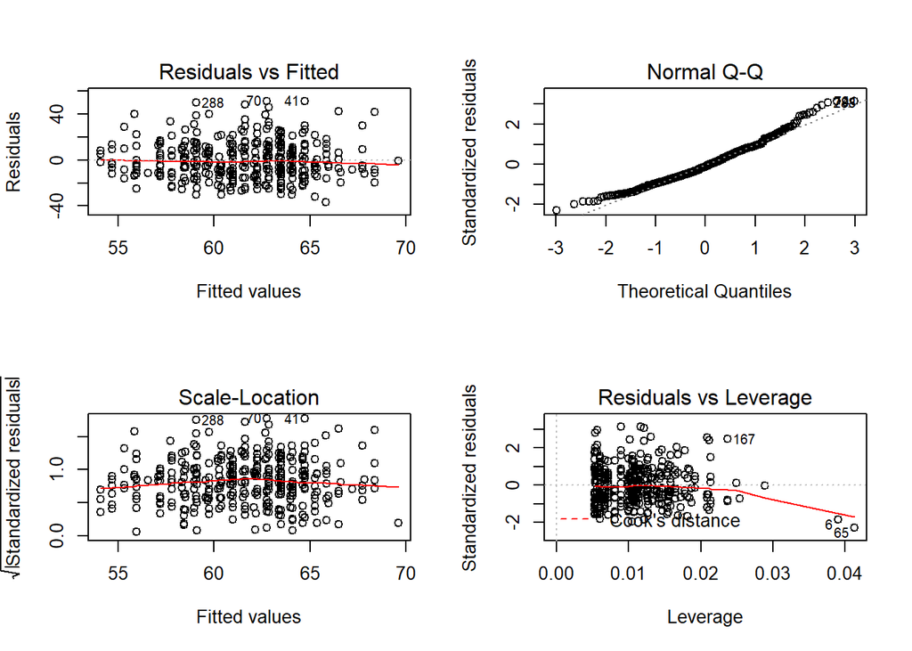

```r
par(mfrow=c(2,2))
plot(stressModel)
```

Looks like english confidence and whether a person has traveled before are both significant predictors, with the former in the negative direction (greater confidence associated less stress) and with those who have not traveled before experiencing more stress (as expected).

A nicer plot of the linear model:

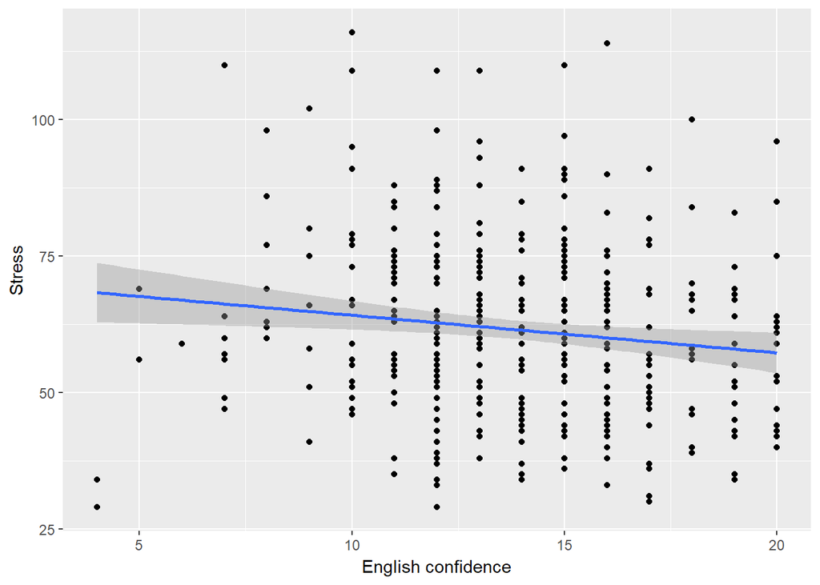

```r
ggplot(filtered, aes(x=english_confidence, y=stress)) + geom_point() + geom_smooth(method="lm") + labs(y="Stress", x="English confidence")
```

Two points on the bottom left look like multivariate outliers, probably have high leverage on the regression equation. Let’s refit the model without these 2 and re-plot.

```r
refiltered <- filtered %>% filter(english_confidence > 4)
stressModel <- lm(stress ~ english_confidence + sex + traveled_before, data = refiltered)
summary(stressModel)
```

```
##
## Call:
## lm(formula = stress ~ english_confidence + sex + traveled_before,
##     data = refiltered)
##
## Residuals:
##     Min      1Q  Median      3Q     Max
## -32.656 -11.806  -1.836  10.589  51.624
##
## Coefficients:
##                              Estimate Std. Error t value Pr(>|t|)
## (Intercept)                   75.4947     4.0182  18.788  < 2e-16 ***
## english_confidence            -0.8199     0.2731  -3.002  0.00287 **
## sexFemale                     -1.8944     1.8353  -1.032  0.30268
## traveled_beforeAbroad before  -3.6614     1.8875  -1.940  0.05320 .
## ---
## Signif. codes:  0 '***' 0.001 '**' 0.01 '*' 0.05 '.' 0.1 ' ' 1
##
## Residual standard error: 16.27 on 354 degrees of freedom
## Multiple R-squared:  0.04185,    Adjusted R-squared:  0.03373
## F-statistic: 5.154 on 3 and 354 DF,  p-value: 0.001688
```

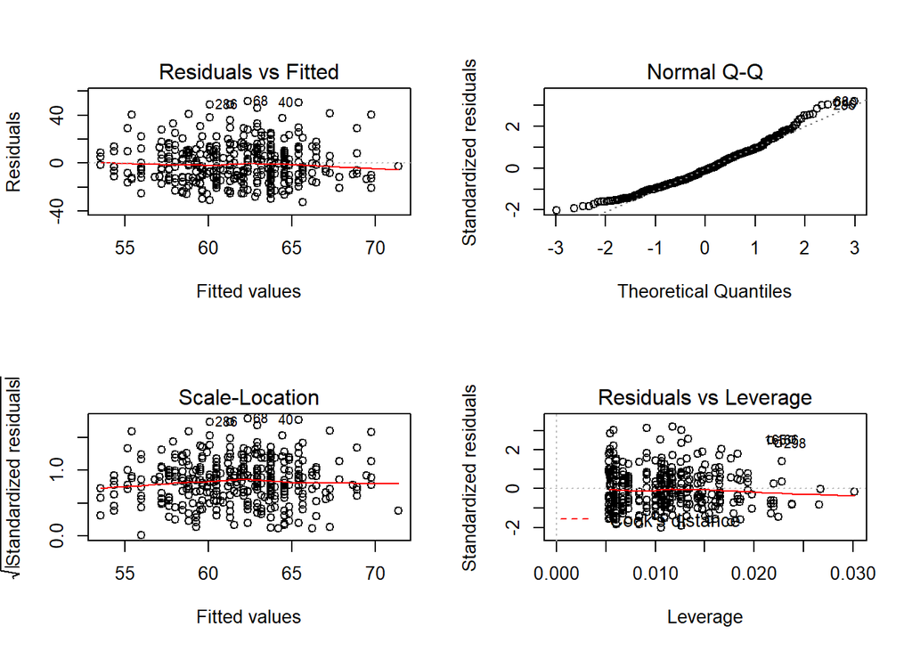

```r
par(mfrow=c(2,2))
plot(stressModel)
```

Residual plots look pretty good now (not perfect - still might try log transformation). Let’s make a nice looking tabular output of the statistical results.

```r
htmlreg(stressModel, type = "html",  digits = 3, bold = .05, booktabs = TRUE, sideways = FALSE, use.packages = FALSE, single.row = FALSE, custom.model.names = "Stress", leading.zero = TRUE, stars = c(0.05, 0.01, 0.001), custom.note = "\\parbox{.4\\linewidth}{\\vspace{2pt}%stars. \\\\Results are as coefficient (standard error).}",  include.nobs = TRUE, include.adjrs = TRUE, include.fstatistic = FALSE, include.rmse = FALSE, custom.coef.map = list('(Intercept)' = '(Constant)', 'english_confidence' = 'English confidence', 'sexFemale' = 'Gender (Female)', 'traveled_beforeAbroad before' = 'Prior travel'), caption = "English confidence predicts stress scores")
```

English confidence predicts stress scores

|  | **Stress** |
| --- | --- |
| (Constant) | **75.495***** |
|  | (4.018) |
| English confidence | **-0.820**** |
|  | (0.273) |
| Gender (Female) | -1.894 |
|  | (1.835) |
| Prior travel | -3.661 |
|  | (1.888) |
| R<sup>2</sup> | 0.042 |
| Adj. R<sup>2</sup> | 0.034 |
| Num. obs. | 358 |

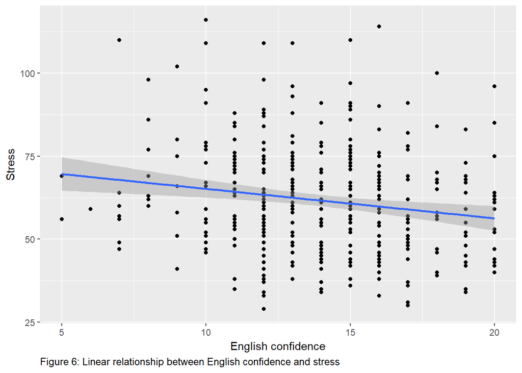

```r
ggplot(refiltered, aes(x=english_confidence, y=stress)) + geom_point() + geom_smooth(method="lm") + labs(y="Stress", x="English confidence", caption = "Figure 6: Linear relationship between English confidence and stress") + theme(plot.caption=element_text(hjust=0))
```

So it seems there’s a nice linear relationship between English confidence and reported levels. The regression output tells us that for a 1 unit increase in “English confidence level” we can expect about a 0.82 point decrease in reported stress level. Whether a participant has traveled before is no longer a significant predictor, but it is very close (sex remains non-significant).

Let’s also make a correlation matrix between potential covariates and stress.

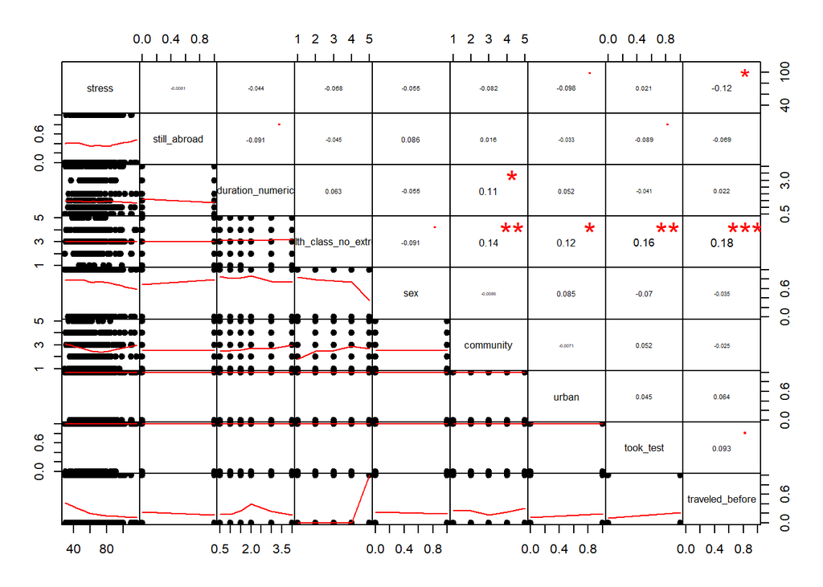

```r
numeric_vars_filtered <- refiltered %>% dplyr::select(stress, still_abroad, duration_numeric, wealth_class_no_extreme, sex, community, urban, took_test, traveled_before) %>% mutate_all(funs(as.numeric(.)))
numeric_vars_filtered$traveled_before <- numeric_vars_filtered$traveled_before - 1
numeric_vars_filtered$still_abroad <- numeric_vars_filtered$still_abroad - 1
numeric_vars_filtered$took_test <- numeric_vars_filtered$took_test - 1
numeric_vars_filtered$sex <- numeric_vars_filtered$sex - 1
numeric_vars_filtered$urban <- numeric_vars_filtered$urban - 1
chart.Correlation(R = numeric_vars_filtered , histogram = FALSE, pch = 19)
```

And we’ll, just to be safe, do a regression with all these control variables to show that the regression parameters don’t change much when they’re included.

```r
eng_conf_with_covs <- lm(stress ~ english_confidence + sex + traveled_before + still_abroad + duration_numeric +  wealth_class_no_extreme + urban, data = refiltered )
summary(eng_conf_with_covs)
```

```
##
## Call:
## lm(formula = stress ~ english_confidence + sex + traveled_before +
##     still_abroad + duration_numeric + wealth_class_no_extreme +
##     urban, data = refiltered)
##
## Residuals:
##     Min      1Q  Median      3Q     Max
## -33.326 -11.946  -1.448   9.910  51.409
##
## Coefficients:
##                                           Estimate Std. Error t value
## (Intercept)                                77.8792     6.1287  12.707
## english_confidence                         -0.7583     0.2813  -2.696
## sexFemale                                  -1.8655     1.8786  -0.993
## traveled_beforeAbroad before               -3.3587     1.9424  -1.729
## still_abroadAlready returned               -0.2415     1.8055  -0.134
## duration_numeric                           -0.1722     0.8188  -0.210
## wealth_class_no_extremeLower-middle class   1.6333     5.3138   0.307
## wealth_class_no_extremeMiddle class        -1.3658     4.9453  -0.276
## wealth_class_no_extremeUpper-middle class  -0.2069     5.0900  -0.041
## wealth_class_no_extremeUpper class         -3.1692     6.4791  -0.489
## urbanUrban                                 -2.7771     2.3345  -1.190
##                                           Pr(>|t|)
## (Intercept)                                < 2e-16 ***
## english_confidence                         0.00736 **
## sexFemale                                  0.32140
## traveled_beforeAbroad before               0.08468 .
## still_abroadAlready returned               0.89367
## duration_numeric                           0.83358
## wealth_class_no_extremeLower-middle class  0.75875
## wealth_class_no_extremeMiddle class        0.78258
## wealth_class_no_extremeUpper-middle class  0.96760
## wealth_class_no_extremeUpper class         0.62505
## urbanUrban                                 0.23502
## ---
## Signif. codes:  0 '***' 0.001 '**' 0.01 '*' 0.05 '.' 0.1 ' ' 1
##
## Residual standard error: 16.35 on 347 degrees of freedom
## Multiple R-squared:  0.05176,    Adjusted R-squared:  0.02443
## F-statistic: 1.894 on 10 and 347 DF,  p-value: 0.04492
```

Now a regression output in a LaTeX table for this model.

```r
htmlreg(eng_conf_with_covs, type = "html",  digits = 3, bold = .05, booktabs = TRUE, sideways = FALSE, use.packages = FALSE, single.row = FALSE, custom.model.names = "Stress", leading.zero = TRUE, stars = c(0.05, 0.01, 0.001), custom.note = "\\parbox{.4\\linewidth}{\\vspace{2pt}%stars. \\\\Results are as coefficient (standard error).}",  include.nobs = TRUE, include.adjrs = TRUE, include.fstatistic = FALSE, include.rmse = FALSE, custom.coef.map = list('(Intercept)' = '(Constant)', `english_confidence` = 'English confidence', 'sexFemale' = 'Gender (Female)', 'traveled_beforeAbroad before' = 'Prior travel', 'still_abroadAlready returned' = 'Already returned from study abroad', 'duration_numeric' = 'Duration abroad', 'urbanUrban' = 'Urban upbringing', 'wealth_class_no_extremeLower-middle class' = 'Lower-middle class wealth - Lower class', 'wealth_class_no_extremeMiddle class' = 'Middle class wealth - Lower class', 'wealth_class_no_extremeUpper-middle class' = 'Upper-middle class wealth - Lower class', 'wealth_class_no_extremeUpper class' = 'Upper class wealth - Lower class'), caption = "Adding additional covariates does not improve model fit")
```

Adding additional covariates does not improve model fit

|  | **Stress** |
| --- | --- |
| (Constant) | **77.879***** |
|  | (6.129) |
| English confidence | **-0.758**** |
|  | (0.281) |
| Gender (Female) | -1.865 |
|  | (1.879) |
| Prior travel | -3.359 |
|  | (1.942) |
| Already returned from study abroad | -0.241 |
|  | (1.805) |
| Duration abroad | -0.172 |
|  | (0.819) |
| Urban upbringing | -2.777 |
|  | (2.335) |
| Lower-middle class wealth - Lower class | 1.633 |
|  | (5.314) |
| Middle class wealth - Lower class | -1.366 |
|  | (4.945) |
| Upper-middle class wealth - Lower class | -0.207 |
|  | (5.090) |
| Upper class wealth - Lower class | -3.169 |
|  | (6.479) |
| R<sup>2</sup> | 0.052 |
| Adj. R<sup>2</sup> | 0.024 |
| Num. obs. | 358 |

## Objective measures; IELTS / TOEFL scores, country effects

Next we’re interested in what other factors we’ve collected data on are predictors of stress - ideally, factors that are more ‘objective’ measures, such as IELTS/TOEFL scores.

To start off we’ll look at whether those who took the test experienced less stress studying abroad than those that did. And we’ll take a look at the counts for number of subjects who did and did not take the test.

```r
took_test_model <- lm(stress ~ took_test + sex + traveled_before, data  = refiltered)
summary(took_test_model)
```

```
##
## Call:
## lm(formula = stress ~ took_test + sex + traveled_before, data = refiltered)
##
## Residuals:
##     Min      1Q  Median      3Q     Max
## -31.660 -11.949  -1.844  10.672  53.357
##
## Coefficients:
##                              Estimate Std. Error t value Pr(>|t|)
## (Intercept)                    63.466      2.493  25.462   <2e-16 ***
## took_testTook test              1.195      2.259   0.529   0.5973
## sexFemale                      -2.018      1.861  -1.084   0.2790
## traveled_beforeAbroad before   -4.420      1.905  -2.320   0.0209 *
## ---
## Signif. codes:  0 '***' 0.001 '**' 0.01 '*' 0.05 '.' 0.1 ' ' 1
##
## Residual standard error: 16.47 on 354 degrees of freedom
## Multiple R-squared:  0.01823,    Adjusted R-squared:  0.009909
## F-statistic: 2.191 on 3 and 354 DF,  p-value: 0.08881
```

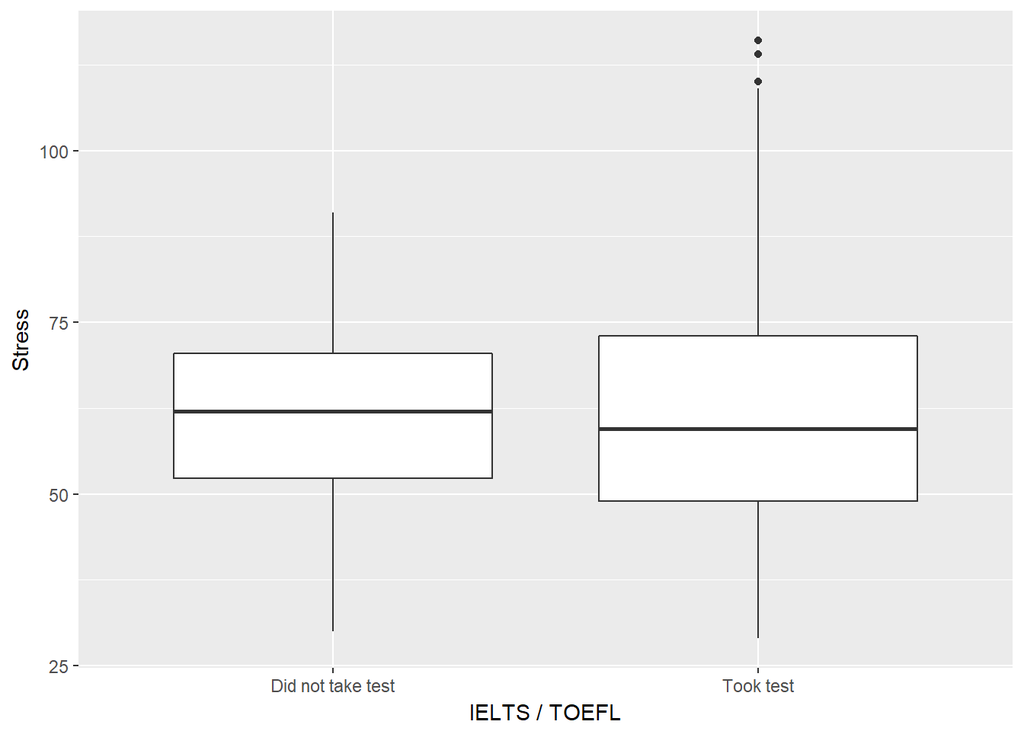

```r
ggplot(refiltered, aes(x=took_test, y=stress)) + geom_boxplot() + labs(x = "IELTS / TOEFL", y="Stress")
```

```r
table(refiltered$took_test)
```

```
##
## Did not take test         Took test
##                66               292
```

Looks like stress levels didn’t differ much according to whether one took the test or not. This doesn’t tell us much about how doing well on the test relates to stress, so next, let’s look at how they relate to the scores themselves (amongst those that took the test). But first we’ll generate a histogram to see our distribution of scores, because we suspect that there many not be many people who received the highest and lowest scores, so those data points may not be very informative in our statistical models. We’ll also produce a table of the counts.

```r
table(refiltered$overall_score_numeric)
```

```
##
## 4.5   5 5.5   6 6.5   7 7.5   8 8.5   9
##   2   3  21  34  70  80  51  25   5   1
```

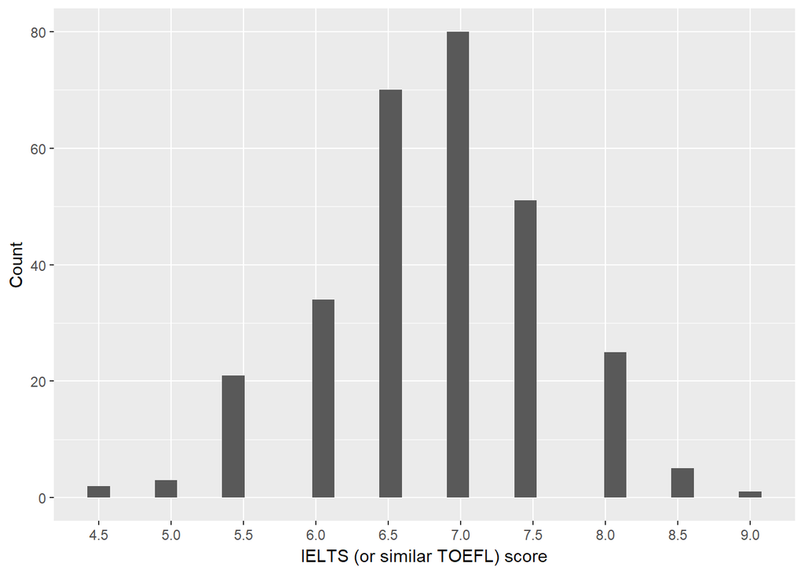

```r
ggplot(refiltered, aes(x=overall_score_numeric)) + geom_histogram() + scale_x_continuous("IELTS (or similar TOEFL) score", breaks = seq(4.5, 9, by=.5), minor_breaks =  NULL) + labs(y = "Count")
```

```r
refiltered$overall_score_numeric_less_trimmed <- refiltered$overall_score_numeric
refiltered$overall_score_numeric_less_trimmed[refiltered$overall_score_numeric_less_trimmed == 9] <- NA
refiltered$overall_score_numeric_less_trimmed[refiltered$overall_score_numeric_less_trimmed == 4.5] <- NA
score_model <- lm(stress ~ overall_score_numeric_less_trimmed + sex + traveled_before, data = refiltered)
summary(score_model)
```

```
##
## Call:
## lm(formula = stress ~ overall_score_numeric_less_trimmed + sex +
##     traveled_before, data = refiltered)
##
## Residuals:
##     Min      1Q  Median      3Q     Max
## -31.307 -13.114  -2.072  10.413  52.650
##
## Coefficients:
##                                    Estimate Std. Error t value Pr(>|t|)
## (Intercept)                         74.2371     9.6680   7.679 2.59e-13
## overall_score_numeric_less_trimmed  -1.5276     1.4132  -1.081   0.2806
## sexFemale                           -0.9573     2.1244  -0.451   0.6526
## traveled_beforeAbroad before        -4.5706     2.1973  -2.080   0.0384
##
## (Intercept)                        ***
## overall_score_numeric_less_trimmed
## sexFemale
## traveled_beforeAbroad before       *
## ---
## Signif. codes:  0 '***' 0.001 '**' 0.01 '*' 0.05 '.' 0.1 ' ' 1
##
## Residual standard error: 17.05 on 285 degrees of freedom
##   (69 observations deleted due to missingness)
## Multiple R-squared:  0.02346,    Adjusted R-squared:  0.01318
## F-statistic: 2.282 on 3 and 285 DF,  p-value: 0.07935
```

```r
htmlreg(score_model, type = "html",  digits = 3, bold = .05, booktabs = TRUE, sideways = FALSE, use.packages = FALSE, single.row = FALSE, custom.model.names = "Stress", leading.zero = TRUE, stars = c(0.05, 0.01, 0.001), custom.note = "\\parbox{.4\\linewidth}{\\vspace{2pt}%stars. \\\\Results are as coefficient (standard error).}",  include.nobs = TRUE, include.adjrs = TRUE, include.fstatistic = FALSE, include.rmse = FALSE, custom.coef.map = list('(Intercept)' = '(Constant)', 'overall_score_numeric_less_trimmed' = 'Test scores', 'sexFemale' = 'Gender (Female)', 'traveled_beforeAbroad before' = 'Prior travel'), caption = "No overall relationship between test scores and stress")
```

No overall relationship between test scores and stress

|  | **Stress** |
| --- | --- |
| (Constant) | **74.237***** |
|  | (9.668) |
| Test scores | -1.528 |
|  | (1.413) |
| Gender (Female) | -0.957 |
|  | (2.124) |
| Prior travel | **-4.571*** |
|  | (2.197) |
| R<sup>2</sup> | 0.023 |
| Adj. R<sup>2</sup> | 0.013 |
| Num. obs. | 289 |

So overall score isn’t a significant predictor at a group level. We’re a little surprised by this result, given that, as shown below, IELTS / TOEFL score is correlated with English confidence, which was associated with stress levels (we’ll come back to this point):

```r
cor.test(refiltered$overall_score_numeric_less_trimmed, refiltered$english_confidence)
```

```
##
##  Pearson's product-moment correlation
##
## data:  refiltered$overall_score_numeric_less_trimmed and refiltered$english_confidence
## t = 6.6503, df = 287, p-value = 1.474e-10
## alternative hypothesis: true correlation is not equal to 0
## 95 percent confidence interval:
##  0.2610370 0.4613391
## sample estimates:
##       cor
## 0.3654104
```

So what might account for this? We hypothesized that the impact of test scores might differ according to where a subject studied abroad - the country where they stayed. First let’s graph stress levels by country, and test whether there are differences by country.

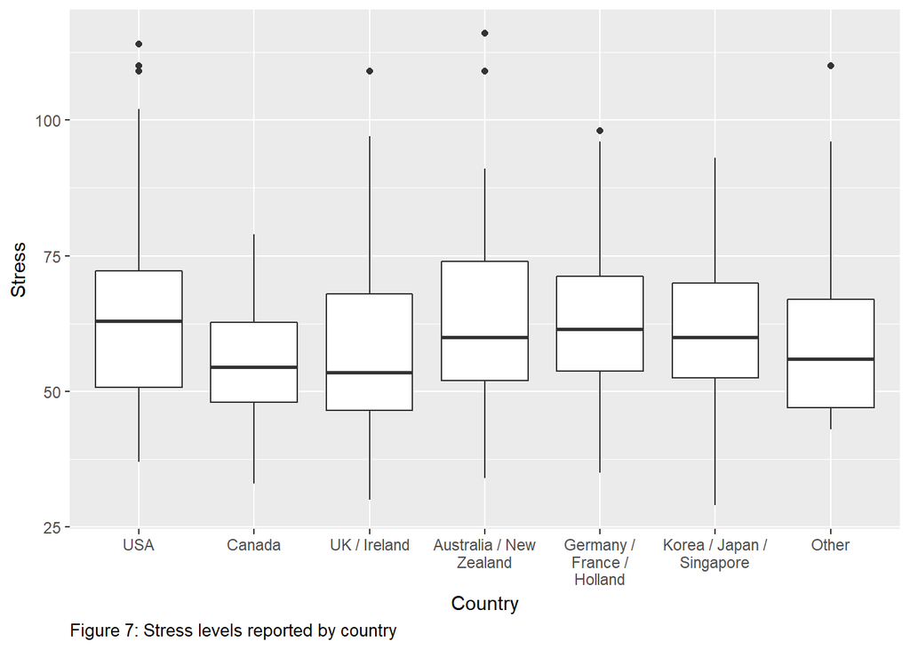

```r
ggplot(refiltered, aes(x=country, y=stress)) + geom_boxplot() + labs(x="Country", y="Stress" , caption = "Figure 7: Stress levels reported by country") + scale_x_discrete(labels = wrap_format(16)) + theme(plot.caption=element_text(hjust=0))
```

```r
stress_by_country <- lm(stress ~ country, data = refiltered)
summary(stress_by_country)
```

```
##
## Call:
## lm(formula = stress ~ country, data = refiltered)
##
## Residuals:
##     Min      1Q  Median      3Q     Max
## -32.875 -11.702  -1.875   9.844  53.178
##
## Coefficients:
##                                   Estimate Std. Error t value Pr(>|t|)
## (Intercept)                         64.094      1.686  38.007   <2e-16 ***
## countryCanada                       -7.821      3.906  -2.003   0.0460 *
## countryUK / Ireland                 -5.518      2.642  -2.089   0.0375 *
## countryAustralia / New Zealand      -1.272      2.566  -0.496   0.6204
## countryGermany / France / Holland   -1.753      3.008  -0.583   0.5605
## countryKorea / Japan / Singapore    -2.219      3.109  -0.714   0.4760
## countryOther                        -2.623      4.348  -0.603   0.5467
## ---
## Signif. codes:  0 '***' 0.001 '**' 0.01 '*' 0.05 '.' 0.1 ' ' 1
##
## Residual standard error: 16.52 on 351 degrees of freedom
## Multiple R-squared:  0.01998,    Adjusted R-squared:  0.003227
## F-statistic: 1.193 on 6 and 351 DF,  p-value: 0.3095
```

```r
Anova(stress_by_country, type = "III")
```

```
## Anova Table (Type III tests)
##
## Response: stress
##             Sum Sq  Df   F value Pr(>F)
## (Intercept) 394369   1 1444.5621 <2e-16 ***
## country       1954   6    1.1926 0.3095
## Residuals    95824 351
## ---
## Signif. codes:  0 '***' 0.001 '**' 0.01 '*' 0.05 '.' 0.1 ' ' 1
```

So it does look like there’s a little heterogeneity in stress levels according to country, with USA students experiencing the most stress. There’s not an overall effect of country but there are a few differences from the US.

```r
htmlreg(stress_by_country, type = "html",  digits = 3, bold = .05, booktabs = TRUE, sideways = FALSE, use.packages = FALSE, single.row = FALSE, custom.model.names = "Stress", leading.zero = TRUE, stars = c(0.05, 0.01, 0.001), custom.note = "\\parbox{.4\\linewidth}{\\vspace{2pt}%stars. \\\\Results are as coefficient (standard error).}",  include.nobs = TRUE, include.adjrs = TRUE, include.fstatistic = FALSE, include.rmse = FALSE, custom.coef.map = list('(Intercept)' = '(Constant)', 'countryCanada' = 'Canada - USA', 'countryUK / Ireland' = ']UK / Ireland - USA', 'countryAustralia / New Zealand' = 'Australia / New Zealand - USA', 'countryGermany / France / Holland' = 'Germany / France / Holland - USA', 'countryKorea / Japan / Singapore' = 'Korea / Japan / Singapore - USA', 'countryOther' = 'Other - USA'), caption = "Differences in stress scores from USA by country")
```

Differences in stress scores from USA by country

|  | **Stress** |
| --- | --- |
| (Constant) | **64.094***** |
|  | (1.686) |
| Canada - USA | **-7.821*** |
|  | (3.906) |
| ]UK / Ireland - USA | **-5.518*** |
|  | (2.642) |
| Australia / New Zealand - USA | -1.272 |
|  | (2.566) |
| Germany / France / Holland - USA | -1.753 |
|  | (3.008) |
| Korea / Japan / Singapore - USA | -2.219 |
|  | (3.109) |
| Other - USA | -2.623 |
|  | (4.348) |
| R<sup>2</sup> | 0.020 |
| Adj. R<sup>2</sup> | 0.003 |
| Num. obs. | 358 |

We’ll proceed with our analysis of whether test scores’ relationship with stress levels differ by county (`overall_score_numeric_trimmed:country` interaction), excluding subjects who responded “Other” since subjects in this group don’t necessarily form a meaningful / cohesive group for statistical analysis.

```r
noOtherCountry <- refiltered %>% filter(country != "Other")
countryModel <- lm(stress ~ overall_score_numeric_less_trimmed * country + sex + traveled_before, data = noOtherCountry)
Anova(countryModel, type = "III")
```

```
## Anova Table (Type III tests)
##
## Response: stress
##                                            Sum Sq  Df F value    Pr(>F)
## (Intercept)                                 10266   1 36.3856 5.469e-09
## overall_score_numeric_less_trimmed           1983   1  7.0301  0.008502
## country                                      2665   5  1.8891  0.096522
## sex                                            15   1  0.0549  0.814979
## traveled_before                              1084   1  3.8407  0.051077
## overall_score_numeric_less_trimmed:country   2478   5  1.7568  0.122103
## Residuals                                   74201 263
##
## (Intercept)                                ***
## overall_score_numeric_less_trimmed         **
## country                                    .
## sex
## traveled_before                            .
## overall_score_numeric_less_trimmed:country
## Residuals
## ---
## Signif. codes:  0 '***' 0.001 '**' 0.01 '*' 0.05 '.' 0.1 ' ' 1
```

```r
Anova(lm(stress ~ english_confidence * country + sex + traveled_before, data = noOtherCountry), type = "III")
```

```
## Anova Table (Type III tests)
##
## Response: stress
##                            Sum Sq  Df  F value    Pr(>F)
## (Intercept)                 37919   1 147.9127 < 2.2e-16 ***
## english_confidence           3216   1  12.5446 0.0004551 ***
## country                      2333   5   1.8203 0.1083385
## sex                            39   1   0.1525 0.6964474
## traveled_before              1389   1   5.4193 0.0205245 *
## english_confidence:country   1670   5   1.3031 0.2622034
## Residuals                   83829 327
## ---
## Signif. codes:  0 '***' 0.001 '**' 0.01 '*' 0.05 '.' 0.1 ' ' 1
```

Here are the marginal means for stress levels by country, followed by the estimates of the slopes for `overall_score_numeric_less_trimmed` by country:

```r
lsmeans(countryModel, ~ overall_score_numeric_less_trimmed * country)
```

```
##  overall_score_numeric_less_trimmed country                      lsmean
##                            6.837545 USA                        66.05463
##                            6.837545 Canada                     54.64908
##                            6.837545 UK / Ireland               58.43142
##                            6.837545 Australia / New Zealand    61.89670
##                            6.837545 Germany / France / Holland 60.84482
##                            6.837545 Korea / Japan / Singapore  61.53002
##        SE  df lower.CL upper.CL
##  1.960160 263 62.19503 69.91424
##  3.947871 263 46.87563 62.42254
##  2.245755 263 54.00947 62.85337
##  2.330855 263 57.30719 66.48621
##  4.112225 263 52.74774 68.94189
##  4.228466 263 53.20407 69.85598
##
## Results are averaged over the levels of: sex, traveled_before
## Confidence level used: 0.95
```